# **R** 菜鸟入门

## 第10篇 函数和包

终于轮到介绍 **R** 的精髓了，那就是包，package。欲知包，必先知函数，function。

我们已经遇到过很多函数了。**R** 中大多数工作都是函数完成的。经验告诉我们，调用函数的格式是：`函数名(变量1 = 某个值，变量2 = 某个值，...)`。我们以前用过的，都是 **R** 基础安装包里有限的一些预先设置好的函数。比如：

```r
x <- 1:5
sd(x)  # sd 是函数名, x 是自变量。
```

```
## [1] 1.58
```

`sd()`用来计算标准差。当我们发出这条指令时，**R** 在幕后到底忙活个啥呢？输入函数名就能看到了：

```r
sd
```

```
## function (x, na.rm = FALSE)
## {
##     if (is.matrix(x)) {
##         msg <- "sd(<matrix>) is deprecated.\n Use apply(*, 2, sd) instead."
##         warning(paste(msg, collapse = ""), call. = FALSE, domain = NA)
##         apply(x, 2, sd, na.rm = na.rm)
##     }
##     else if (is.vector(x))
##         sqrt(var(x, na.rm = na.rm))
##     else if (is.data.frame(x)) {
##         msg <- "sd(<data.frame>) is deprecated.\n Use sapply(*, sd) instead."
##         warning(paste(msg, collapse = ""), call. = FALSE, domain = NA)
##         sapply(x, sd, na.rm = na.rm)
##     }
##     else sqrt(var(as.vector(x), na.rm = na.rm))
## }
## <bytecode: 0x053ba43c>
## <environment: namespace:stats>
```

甚至 `x <- 1:5` 这一句，其实背后运行的也是个函数，等同于：

```
assign("x", 1:5)
```

内置函数虽然功能强大，但是毕竟有限，要是能随心所欲自己定义新函数就好了。这一点 **R** 贴心地考虑到了。比如说，当年有一回全班考得都很惨，老师心软了，说为了提高及格率，把卷面分数开方乘十作为新分数吧。为了以后经常用来提高及格率，我们可以专门定义这样一个函数，完全仿照内置函数的格式：

```r
newscore <- function(x) {
    # newscore 是自定义的函数名，它有一个自变量 x。函数的返回值是 sqrt(x) * 10。
    sqrt(x) * 10
}
```

以后当考了40分的时候，可以这样调用你的新函数：

```r
newscore(x = 40)
```

```
## [1] 63.2
```

*开胃小菜：更妙的操作方式，想一次可以用很久喔！有人說，學電腦的人，動腦筋就是為了偷懶。– 语出[大家來學VIM](http://www.study-area.org/tips/vim/index.html)*

上面这个例子中，自变量 x 只是用来在函数内部传递信息用的，不会影响函数之外的对象。看看这个例子：

```r
x <- 36
y <- 81
newscore(x = y)  # 函数内部的 x 把 81 的值传递进来，而不是36。
```

```
## [1] 90
```

可以有多个自变量：

```r
news <- function(x, n) {
    sqrt(x) * 10 + n
}
news(x = 36, n = 10)
```

```
## [1] 70
```

```r
news(36, 10)  # 懒人为了省事儿，按自变量的默认顺序写就行了。
```

```
## [1] 70
```

```r
news(n = 10, x = 36)  # 如果打乱顺序，就必须指定谁是谁。
```

```
## [1] 70
```

每次调用自定义函数 newscore 的时候，必须提供所有自变量的取值，否则就会报错：

```r
newscore()
```

```
## Error: 'x' is missing
```

为避免这个问题，需要给个默认值：

```r
newscore <- function(x = 36) {
    # x 默认是 36。
    sqrt(x) * 10
}
newscore()
```

```
## [1] 60
```

给函数定义时，我们用了花括号{}，这意味着可以把一组操作都放进去，哪怕这一组操作有千万行，以后只用一行就可以调用一遍了！比如第 05 篇提到过的指数增长，可以定义一个函数`exponentialGrowth`：

```r
exponentialGrowth <- function(N0, r = 0.01, tmax = 10) {
    # 三个自变量：初始值，增长率，时间。
    N <- N0
    for (t in 1:(tmax - 1)) {
        N[t + 1] <- N[t] + r * N[t]
    }
    N  # 这是最后一行，作为函数的返回值。
}

exponentialGrowth(66.8)
```

```
##  [1] 66.8 67.5 68.1 68.8 69.5 70.2 70.9 71.6 72.3 73.1
```

[figure not shown]

```
练习10.1 自定义一个名为 kaifang 的函数，用来开平方。
练习10.2 自定义一个名为 cv 的函数，用来计算变异系数，即 标准差除以平均值的商。
```

```r
plot(exponentialGrowth(66.8, 0.01, 100))
```

上面我们自定义了几个函数。世界上很多角落都有想把 36 分变成 60 分的苦命同学，为了让他们也能方便地调用我们自定义的函数，我们可以把它们打包上传到服务器上，这样别人下载了就可以直接用。这就是包。包就是一组预设函数的集合，有时候也包含一些数据。一个包里可能只有一个函数，也可能有成千上万个。**R** 能走到今天，是一个聚沙成塔、集腋成裘的过程，其中的沙和腋，正是众多热心人花心血写成并奉献出来的扩展包。每个人献出一滴水，终于创造出如今的汪洋大海任你畅游。到底有多少个扩展包呢？用这条命令：

```
length(unique(rownames(available.packages())))
```

扩展包是 **R** 的生命力所在。找到一个合适的扩展包，能起到事半功倍的效果。甚至可以说，会用扩展包，比本文前9篇介绍的所有内容都重要！很多人用 **R** 就是奔着扩展包来的。

还是举个例子吧。

北京有个著名的广场，常年根据预测的日出日落时间来确定[升降国旗仪式的时间](http://www.tiananmen.org.cn/flag/index.asp)，这个是怎么预测的？参看[这里](http://www.ubeijing.cn/zhinan/2557.html)。日出日落时间的计算是可以当作[新闻](http://news.lnd.com.cn/htm/2008-07/07/content_236459.htm)来报导的，这让 dapeng 觉得挺神秘。直到有一天，dapeng 需要把某个观测点半年的气温数据（每半小时一条）分为白天和黑夜两组，那么就要判断当地每天的日出和日落时间，不得不设法揭开这个神秘面纱了。上网一搜，哦买告的，计算过程不是一般的复杂啊（见[这里](http://www.joyloft.net/?p=456)），需要有三角函数知识、立体几何知识、天文学知识等等等等，最要命的是还得有足够的耐心。dapeng 花了大概一天的工夫，硬着头皮算出了个数，却跟实际对不上号。

后来，惊喜地发现了 maptools 这个扩展包，安装这个包之后，用其中的 `sunriset()` 函数一条指令轻松搞定。前天是一个重要的日子，我们计算一下当天的升降国旗时间。

```
install.packages("maptools") # 第一次使用某个扩展包时要先安装。
```

```r
require(maptools)  # 调用扩展包，让 R 识别其中的函数。
position <- c(116.39, 39.91)  # 旗杆的经纬度。
mydate <- "2013-03-24"  # 要计算的日期。
sunriset(matrix(position, nrow = 1), as.POSIXct(mydate, tz = "Asia/Shanghai"),
    direction = c("sunrise"), POSIXct.out = TRUE)$time  # 日出时间。
```

```
## [1] "2013-03-24 06:11:53 CST"
```

```r
sunriset(matrix(position, nrow = 1), as.POSIXct(mydate, tz = "Asia/Shanghai"),
    direction = c("sunset"), POSIXct.out = TRUE)$time  # 日落时间。
```

```
## [1] "2013-03-24 18:30:15 CST"
```

跟官方公布的一点也不差。一个完整的扩展包包括了帮助信息，所以我们的法宝问号仍然管用。自己试试 '?sunriset'。若要了解整个扩展包中所有的函数，可以 google 搜索 'cran maptools'，也可以在本地计算机 **R** 的安装路径下面 library 文件夹中找到。

让我们更进一步，自定义一个函数，计算该广场任意一段时期的升降旗时刻：

```r
flag <- function(date.start = "2013-03-24", date.length = 7) {
    # 函数名为flag，默认是计算从前天起一周的升降器时刻。
    mydate <- seq(as.POSIXct(date.start, tz = "Asia/Shanghai"), by = 3600 *
        24, length.out = date.length)
    data.frame(sunrise = sunriset(matrix(c(116.39, 39.91), nrow = 1), as.POSIXct(mydate,
        tz = "Asia/Shanghai"), direction = c("sunrise"), POSIXct.out = TRUE)$time,
        sunset = sunriset(matrix(c(116.39, 39.91), nrow = 1), as.POSIXct(mydate,
            tz = "Asia/Shanghai"), direction = c("sunset"), POSIXct.out = TRUE)$time)
}

flag("2013-10-01")  # 好了，以后调用这个函数就能很方便计算。
```

```
##               sunrise              sunset
## 1 2013-10-01 06:10:24 2013-10-01 17:57:17
## 2 2013-10-02 06:11:22 2013-10-02 17:55:40
## 3 2013-10-03 06:12:21 2013-10-03 17:54:03
## 4 2013-10-04 06:13:20 2013-10-04 17:52:27
## 5 2013-10-05 06:14:20 2013-10-05 17:50:51
## 6 2013-10-06 06:15:19 2013-10-06 17:49:16
## 7 2013-10-07 06:16:19 2013-10-07 17:47:41
```

如果你懒得自己算，只想知道某地的日出日落时刻，请给 dapeng 留言。[这里](http://dapengde.com/sunriset)是已经计算的北京等地今后三年的日出日落时刻表。

```
练习10.3 利用google earth 查出你所在地点的经纬度，然后利用 maptools 扩展包，计算你所在地点 2013 -2113 年 100 年的日出日落时间，然后通知记者来报导“退休职工某某某计算出某地日出日落时间表”。
```

再举个例子。谢益辉开发了一个制作动画的扩展包，很有趣：

```
install.packages("animation")
require(animation)
demo("fireworks") # 会用网页浏览器打开一个动画。
citation("animation") # 看看作者。
```

看着那些琳琅满目的扩展包，dapeng 有种逛苹果商场看app的感觉。网上看到说，[“陈红是陈凯歌的第四任妻子，从此之后，陈凯歌再也没有过绯闻。记者采访陈红，拴住大导演的心的秘诀是什么？陈红简单的回答，做百变女人。”](http://i.ifeng.com/video/fhtese/qqsrx/news?vt=5&aid=56044505&mid=&m=1)扩展包让 **R** 成了魅力十足的百变女人，教人如何不爱她？

## 有用的信息：

| - | - |
| --- | --- |
| 自定义函数 | `function()` |
| 扩展包 | `install.packages(), require(), citation()` |

## 第11篇 空间数据

写到这里，三大秘诀和三大法宝亮过相了，基本操作介绍过了，扩展包也华丽登过场了，基本上，菜鸟们已经可以独立折腾了，这个系列的帖子也写不下去了。不过，第 05 篇提到过画地图的问题，就再多写一篇介绍一下空间数据吧。

*开胃小菜: 这就是 R。这里没有做不到，只有想不到。（This is R. There is no if. Only how. by Simon Blomberg.)*

空间数据，也就是地理信息系统 GIS 的数据，很多人都用昂贵的 ArcGIS 软件来处理。其实，免费的**R** 配上强大的扩展包，也能够处理很多 GIS 问题，有时甚至更灵活。老实说， dapeng 对 GIS 用得不多，这一篇也就不得不讲得浅显，见谅了。感兴趣的菜鸟可以看[这里](http://cran.r-project.org/web/views/Spatial.html)、[这里](http://spatial-analyst.net/)以及[这本书](http://www.amazon.com/Applied-Spatial-Data-Analysis-Use/dp/0387781706)。

这里，我们一起在中国地图上，各省份区域用不同颜色来区分，颜色代表该省 PM10 的质量浓度。请先点击[这里](http://sdrv.ms/Zuwe5U)下载地图。这是个压缩包，下载后请解压缩到 *c:\R\data\chinamap\* 文件夹。这个文件夹下应该有三个文件，即 bou2_4p.dbf，bou2_4p.shp，bou2_4p.shx。

```r
require(rgdal)  # 用来处理 GIS 数据的扩展包。若是第一次使用，请自行安装。
```

```r
require(plotrix)  # 用来画图例的扩展包。自行安装
cm <- readOGR("C:\\R\\data\\chinamap", "bou2_4p")  # 读入 GIS 数据
```

```
## with 925 features and 7 fields
## Feature type: wkbPolygon with 2 dimensions
```

```r
summary(cm)
```

```
## Object of class SpatialPolygonsDataFrame
## Coordinates:
##     min   max
## x 73.45 135.1
## y  6.32  53.6
## Is projected: NA
## proj4string : [NA]
## Data attributes:
##       AREA       PERIMETER        BOU2_4M_     BOU2_4M_ID
##  Min.   :  0   Min.   :  0.0   Min.   :  2   Min.   :   0
##  1st Qu.:  0   1st Qu.:  0.0   1st Qu.:233   1st Qu.: 588
##  Median :  0   Median :  0.0   Median :464   Median :2235
##  Mean   :  1   Mean   :  1.5   Mean   :464   Mean   :1856
##  3rd Qu.:  0   3rd Qu.:  0.1   3rd Qu.:695   3rd Qu.:3004
##  Max.   :176   Max.   :129.9   Max.   :926   Max.   :3338
##
##     ADCODE93         ADCODE99           NAME
##  Min.   :     0   Min.   :     0   浙江省 :179
##  1st Qu.:330000   1st Qu.:330000   福建省 :168
##  Median :350000   Median :350000   广东省 :154
##  Mean   :405762   Mean   :405751   辽宁省 : 94
##  3rd Qu.:440000   3rd Qu.:440000   山东省 : 86
##  Max.   :810000   Max.   :810000   (Other):243
##                                    NA's   :  1
```

```r
levels(cm$NAME)  # 省市名称。
```

```
##  [1] "安徽省"           "北京市"           "福建省"
##  [4] "甘肃省"           "广东省"           "广西壮族自治区"
##  [7] "贵州省"           "海南省"           "河北省"
## [10] "河南省"           "黑龙江省"         "湖北省"
## [13] "湖南省"           "吉林省"           "江苏省"
## [16] "江西省"           "辽宁省"           "内蒙古自治区"
## [19] "宁夏回族自治区"   "青海省"           "山东省"
## [22] "山西省"           "陕西省"           "上海市"
## [25] "四川省"           "台湾省"           "天津市"
## [28] "西藏自治区"       "香港特别行政区"   "新疆维吾尔自治区"
## [31] "云南省"           "浙江省"           "重庆市"
```

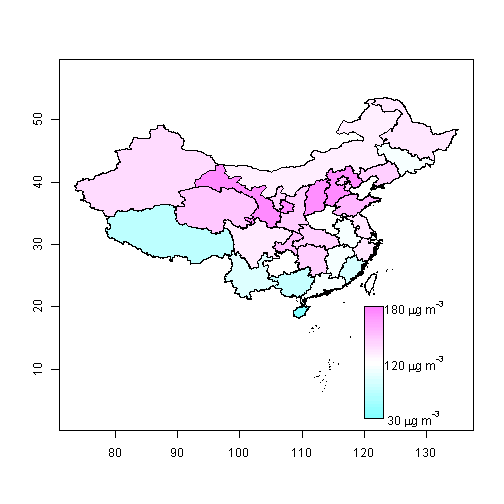

```r
pm <- c(100, 141, 80, 174, 99, 72, 104, 30, 175, 107, 121, 133, 135, 98, 120,
    100, 135, 116, 132, 139, 149, 172, 136, 97, 118, NA, 133, 65, NA, 127, 86,
    119, 147)  # 按照上一条指令得到的省市名称的顺序，对应的省会城市 PM10 质量浓度。恕 dapeng 无法提供数据来源，就当瞎编的吧。
pm.col <- cm.colors(diff(c(30, 180)) + 1)[(pm - min(pm, na.rm = TRUE)) + 1]  # 将 PM10 浓度用颜色代码表示。
cm$col <- cm$NAME  # 添加一列颜色列，与省市名称相同。
levels(cm$col) <- pm.col  # 更改颜色列的因子。
plot(cm, col = as.character(factor(cm$col)))  # 作图
color.legend(120, 20, 123, 2, c(expression("180 " * mu * "g m"^"-3"), expression("120 " *
    mu * "g m"^"-3"), expression(" 30 " * mu * "g m"^"-3")), rev(cm.colors(diff(c(30,
    100)) + 1)), align = "rb", gradient = "y")  # 添加图例。
axis(1)
axis(2)
box()
```

颜色越蓝，PM10 浓度越低。跟北京相比，上海虽然有死猪，但 PM10 浓度还是要低很多的。

```
练习 11.1 从 http://www.diva-gis.org/gdata 免费下载你感兴趣的 GIS 地图，画出来，并更改各区域的颜色。
```

## 第12篇 动画

**R** 有很多种制作动画的方法，一般都是先做出多幅静态图片，再连续播放就可以了。下面这个例子是用 `image()` 函数做出静态图片，用循环指令来连续播放。

```
# 康威生命游戏。内容请咨询维基。
require(simecol) # 调用这个扩展包是为了使用其中的 eightneighbours() 函数。
m <- matrix(0, 40, 40)
m[5:35,19:21] <- 1 # 初始条件。0 表示该位置没有细胞，1 表示有细胞。
image(m, col=c("white", "darkgreen"), axes=FALSE) # 白色表示没有细胞，绿色有细胞。
for (i in 1:200) {
  nn <- eightneighbours(m)
  m.old <- m
  m[m.old == 0 & nn == 3] <- 1 # 当周围有三个细胞时该位置产生细胞。
  m[m.old == 1 & (nn < 2 | nn > 3)] <- 0 # 当周围细胞少于 2 个（太孤单）或大于 3 个（太拥挤）时，该位置细胞死亡。
  image(m, col=c("white", "darkgreen"), axes=FALSE)
  Sys.sleep(0.1)
}
```

[figure not shown]

看到有趣的动画了吧？那么如何保存下来呢？只要在作图前后增加打开和关闭图片的函数就可以了，比如存成png格式的图片：

```
png(paste("c:\\R\\data\\conway_", formatC(i, width = 2, flag = "0"), ".png", sep = ""), width = 300, height = 300)
image(m, col=c("white", "darkgreen"), axes = FALSE)
dev.off()
```

然后用其他免费软件，比如ffmpeg或者imagemagick，把图片连成动画即可。

如果安装了imagemagick，那么三维动画可以用 rgl 扩展包做出来。

```
require(rgl)
x <- sort(rnorm(1000))
y <- rnorm(1000)
z <- rnorm(1000) + atan2(x,y)
plot3d(x, y, z, col = rainbow(1000), type = "s", size = 1, alpha = 0.5) # 作图。
movie3d(spin3d(axis = c(0, 0, 1), rpm = 6), movie = "c:\\R\\data\\movie", duration = 10, clean = TRUE) # 先做出一系列图片，再调用 imagemagick 生成动画。
```

这就是图 00.2 的来历。

## 第13篇 延伸阅读

写完这个系列的时候，复活节假期即将开始，拜罗伊特的晴天渐渐多了，春天早就迫不及待要到来了，可是冬天死活赖着不走，雪竟然飘了一夜，今早外面又是白茫茫一片。

这一系列帖子，本来是打算整理一下拜罗伊特大学 *Introduction to R* 的课程讲义，后来 dapeng 觉得可能没有几个人会对斑马纹贻贝的分布情况感兴趣，因此就把举例用的数据换成了更有趣的 PM2.5，当然，也是为了吸引眼球，盼望着那些搜索 PM2.5 的网友误打误撞摸到这里来邂逅 **R**。这样写着写着，就变成了 dapeng 自己的学习心得，离讲义倒是越来越远了。不过，讲义中 90 % 的要点都包含进来了。另外 10 % 呢？因为，因为整理得不及时，这部分给忘掉了，现在已经看不懂了。不过并不要紧，让菜鸟入门的目的应该基本可以达到。

虽然可能只有几个好友来读，不过写完之后，还是松了一口气，算是给了自己一个交代。每次 dapeng 看着老婆对着经常崩溃的 sigmaplot 和经常用鼠标拖来拖去的 Excel 唉声叹气的时候，真心希望她能用上 **R**。不过后来发现，这多半是一种奢望。**R** 再好，**LATEX** 再好，**Vim** 再好，自己享用而已，即便身边最亲近的人也难以强加。那么，这个系列就算是写给过去的自己吧。如果真能穿越回到五年前，dapeng 会把这套学习笔记悄悄发到当时所用的email信箱里。想想当时的 dapeng 正在硬着头皮读 *Introduction to R* 和 *R for beginners* 这两本书，正在奇怪这两本号称入门级的教材为何自己无论如何就是读不懂，正在羡慕师姐书架上那厚厚的统计学教材。dapeng 一度怀疑自己的智商有问题。后来，加入了现在所在的研究组。周围的人都在用，**R** 代码满天飞，抓住一个，抓耳挠腮地修改一下，凑合着用到自己的数据处理上，几次下来总算是开了窍，这个过程很艰辛。回过头来看，那两本书真的不适合菜鸟。希望 **R 菜鸟入门** 能够让一些人跳过这个艰辛的阶段。

一旦跳过这个阶段，有些书就容易读了。 dapeng 推荐菜鸟们下一步读读下面这些资料。虽然这些资料在网上都能找得到下载，但是请恕 dapeng 只提供了部分下载的链接，这是考虑到版权，有些书的下载是侵权的。为了保护对原书作者的起码尊重，为了以后我们仍然有书可读，能买正版的还是尽量去买正版吧。

- Zuur, Ieno, Meesters 的 [A beginners' guide to R](http://www.highstat.com/book3.htm)

[figure not shown]

入门首选的第一本书。再也找不到哪本书能比这一本写得更浅显易懂了（**R 菜鸟入门** 除外）。也是从课程讲义发展而来的。话说当年 dapeng 在学校图书馆找到这本书时，怎一个惊喜了得。点击上面的链接可以下载书中举例的数据和代码。有中译本。

- Teetor 的 [25 Recipes for Getting Started with R](http://shop.oreilly.com/product/0636920018315.do)

[figure not shown]

实在是很好的入门读物，查阅很方便。中译本由陈钢翻译，叫做 [R 入门25招](http://gossipcoder.com/?p=540)，翻译得很好，译者免费放在了自己的博客上。话说 dapeng 写 **R 菜鸟入门** 写了不到一半的时候读了此书的中译本，差点中途放弃。

- [代码学校](http://tryr.codeschool.com/)

这个网站是 yangliufr 网友推荐的，是个在线课程，可以用实际操作的方式学习。很棒。感谢 yangliufr。

- Crawley 的 [The R Book](http://www.amazon.com/The-Book-Michael-J-Crawley/dp/0470973927)

[figure not shown]

好厚的一本书啊！1000 页！不过真的很好。第二版的中译本正在翻译中，不久就会面世。很好奇书名会翻译成什么。

- 刘思喆的 153分钟学会r(r常见问题解答)  
  菜鸟必备，适合入门不久后有一定使用经验时查阅。

读完这些，就可以进阶读[这里](http://xccds1977.blogspot.de/2013/02/r.html)推荐的书了。

正如第 00 篇所说，这个信息时代，书不是太少，而是太多。菜鸟入门的话，空读多少本关于 **R** 的书，也不如拿几个例子和代码来实际操作一下更有效。经常用 **R** 来工作和消遣，也许会很慢，不过，享受乐趣的过程是越慢越好。携 **R** 之手，与 **R** 偕老，终究你会爱上她的。

因为，在 **R** 的世界里，只有想不到，没有做不到。

( *全文完* )